# Final Project

Michael Bernier

2022-05-01

## Scenario

You are hired as a Senior Data Scientist in Bank of Universe (BOU). BOU is a private company founded twenty years ago and now has more than 5,000 employees. BOU did all the research, chose the insurance company, and picked plan options for employees twenty years ago. The new CEO, Mr. Buffet, wants to make changes and offer self-funded Health Plans (SHP) starting next year. SHP is cheaper for BOU, since BOU dies not have to pay for the separate insurance carrier by taking some risks. BOU has received several years’ medical costs in file insurance.csv from the current insurance carrier.

Download the insurance.csv file. The data source is Kaggle. The file contains the following columns:

- age: age of primary beneficiary.
- sex: insurance contractor gender, female or male.
- bmi: Body mass index, providing an understanding of body, weights that are relatively high or low relative to height, objective index of body weight (kg / m ˆ 2) using the ratio of height to weight, ideally 18.5 to 24.9.
- children: Number of children covered by health insurance / Number of dependents.
- smoker: smoking.
- region: the beneficiary’s residential area in the US, northeast, southeast, southwest, northwest.
- charges: individual medical costs billed by health insurance

### Part 1 - Data Preparation

#### Step a - Open a rmd, load libraries, and load the dataset

```r
library(ggplot2)
library(dplyr)
library(tree)
library(randomForest)
library(factoextra)
library(cluster)
insurance <- read.csv("insurance.csv")
head(insurance)
```

```
##   age    sex    bmi children smoker    region   charges
## 1  19 female 27.900        0    yes southwest 16884.924
## 2  18   male 33.770        1     no southeast  1725.552
## 3  28   male 33.000        3     no southeast  4449.462
## 4  33   male 22.705        0     no northwest 21984.471
## 5  32   male 28.880        0     no northwest  3866.855
## 6  31 female 25.740        0     no southeast  3756.622
```

```r
summary(insurance)
```

```
##       age            sex                 bmi           children
##  Min.   :18.00   Length:1338        Min.   :15.96   Min.   :0.000
##  1st Qu.:27.00   Class :character   1st Qu.:26.30   1st Qu.:0.000
##  Median :39.00   Mode  :character   Median :30.40   Median :1.000
##  Mean   :39.21                      Mean   :30.66   Mean   :1.095
##  3rd Qu.:51.00                      3rd Qu.:34.69   3rd Qu.:2.000
##  Max.   :64.00                      Max.   :53.13   Max.   :5.000
##     smoker             region             charges
##  Length:1338        Length:1338        Min.   : 1122
##  Class :character   Class :character   1st Qu.: 4740
##  Mode  :character   Mode  :character   Median : 9382
##                                        Mean   :13270
##                                        3rd Qu.:16640
##                                        Max.   :63770
```

#### Step b(1) - In the data frame, log transform the variable charges and name it as log_charges

```r
insurance$log_charges <- log(insurance$charges)
summary(insurance)
```

```
##       age            sex                 bmi           children
##  Min.   :18.00   Length:1338        Min.   :15.96   Min.   :0.000
##  1st Qu.:27.00   Class :character   1st Qu.:26.30   1st Qu.:0.000
##  Median :39.00   Mode  :character   Median :30.40   Median :1.000
##  Mean   :39.21                      Mean   :30.66   Mean   :1.095
##  3rd Qu.:51.00                      3rd Qu.:34.69   3rd Qu.:2.000
##  Max.   :64.00                      Max.   :53.13   Max.   :5.000
##     smoker             region             charges       log_charges
##  Length:1338        Length:1338        Min.   : 1122   Min.   : 7.023
##  Class :character   Class :character   1st Qu.: 4740   1st Qu.: 8.464
##  Mode  :character   Mode  :character   Median : 9382   Median : 9.147
##                                        Mean   :13270   Mean   : 9.099
##                                        3rd Qu.:16640   3rd Qu.: 9.720
##                                        Max.   :63770   Max.   :11.063
```

#### Step b(2) - convert columns sex, smoker, and region to factors

```r
insurance$sex <- as.factor(insurance$sex)
insurance$smoker <- as.factor(insurance$smoker)
insurance$region <- as.factor(insurance$region)
summary(insurance)
```

```
##       age            sex           bmi           children     smoker
##  Min.   :18.00   female:662   Min.   :15.96   Min.   :0.000   no :1064
##  1st Qu.:27.00   male  :676   1st Qu.:26.30   1st Qu.:0.000   yes: 274
##  Median :39.00                Median :30.40   Median :1.000
##  Mean   :39.21                Mean   :30.66   Mean   :1.095
##  3rd Qu.:51.00                3rd Qu.:34.69   3rd Qu.:2.000
##  Max.   :64.00                Max.   :53.13   Max.   :5.000
##        region       charges       log_charges
##  northeast:324   Min.   : 1122   Min.   : 7.023
##  northwest:325   1st Qu.: 4740   1st Qu.: 8.464
##  southeast:364   Median : 9382   Median : 9.147
##  southwest:325   Mean   :13270   Mean   : 9.099
##                  3rd Qu.:16640   3rd Qu.: 9.720
##                  Max.   :63770   Max.   :11.063
```

#### Step c - use the sample() function with set.seed equal to 1 to generate row indexes for your training and test sets, with 70% of the row indexes for your training set and 30% for your test set. Do not use any method other than the sample() function for splitting your data.

```r
set.seed(1)
index <- sample(1:nrow(insurance), nrow(insurance)*0.70)
train <- insurance[index,]
test <- insurance[-index,]
```

### Part 2 - Build a multiple regression model

#### Step a - Perform multiple linear regression with log_charges as the response and the predictors are age, sex, bmi, children, smoker, and region. Print out the results using the summary () function. Use the training dataset you created in #1 above.

```r
insurance.multi.regression <- lm(log_charges ~ age + sex + bmi + children + smoker + region, data = train)
summary(insurance.multi.regression)
```

```
##
## Call:
## lm(formula = log_charges ~ age + sex + bmi + children + smoker +
##     region, data = train)
##
## Residuals:
##      Min       1Q   Median       3Q      Max
## -1.03524 -0.17125 -0.03964  0.06275  2.11914
##
## Coefficients:
##                  Estimate Std. Error t value Pr(>|t|)
## (Intercept)      7.052139   0.081384  86.653  < 2e-16 ***
## age              0.034948   0.001005  34.785  < 2e-16 ***
## sexmale         -0.057167   0.027939  -2.046 0.041022 *
## bmi              0.011503   0.002394   4.804 1.81e-06 ***
## children         0.099796   0.011625   8.585  < 2e-16 ***
## smokeryes        1.540724   0.034743  44.347  < 2e-16 ***
## regionnorthwest -0.090603   0.039661  -2.284 0.022571 *
## regionsoutheast -0.140780   0.039344  -3.578 0.000364 ***
## regionsouthwest -0.112012   0.040208  -2.786 0.005449 **
## ---
## Signif. codes:  0 '***' 0.001 '**' 0.01 '*' 0.05 '.' 0.1 ' ' 1
##
## Residual standard error: 0.4246 on 927 degrees of freedom
## Multiple R-squared:  0.7841, Adjusted R-squared:  0.7822
## F-statistic: 420.8 on 8 and 927 DF,  p-value: < 2.2e-16
```

#### Step b - Is there a relationship between the predictors and the response?

Yes, there is a relationship between several of the predictors and the response.

- Strong relationships with age, bmi, children, smoker = yes, and region = southeast
- Moderate relationship with region = southwest
- Minor relationships with sex = male and region = northwest.

#### Step d - Compare the test error of the model in 2a. Report the RMSE.

```r
yhat_mr = predict(insurance.multi.regression, newdata = test)
insurance.multi.regression.test = test[,"log_charges"]
RMSE_mr <- mean((yhat_mr-insurance.multi.regression.test)^2)
print(RMSE_mr)
```

```
## [1] 0.2392122
```

### Part 3 - Build a regression tree model

#### Step a - Build a regression tree model using function tree (), where log_charges is the response and the predictors are age, sex, bmi, children, smoker, and region.

```r
insurance.tree.model <- tree(log_charges ~ age + sex + bmi + children + smoker + region, data=train)
summary(insurance.tree.model)
```

```
##
## Regression tree:
## tree(formula = log_charges ~ age + sex + bmi + children + smoker +
##     region, data = train)
## Variables actually used in tree construction:
## [1] "smoker"   "age"      "children" "bmi"
## Number of terminal nodes:  8
## Residual mean deviance:  0.136 = 126.2 / 928
## Distribution of residuals:
##     Min.  1st Qu.   Median     Mean  3rd Qu.     Max.
## -0.84430 -0.19100 -0.04892  0.00000  0.08654  2.39900
```

#### Step b - Find the optimal tree and display the results in a graphic. Report the best size.

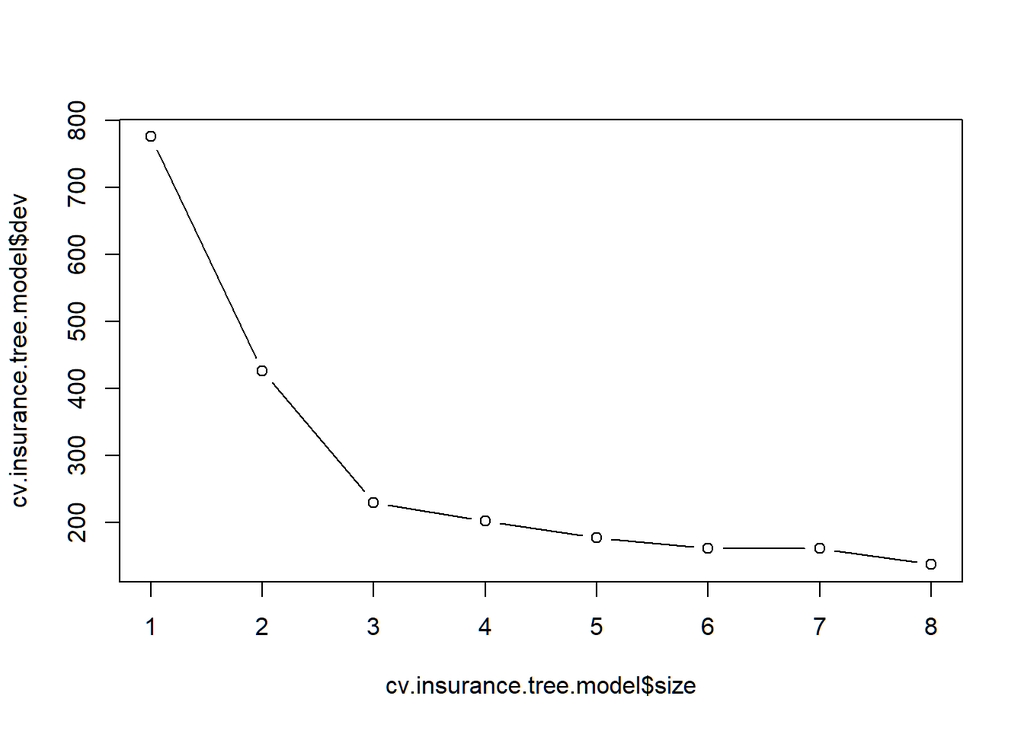

```r
cv.insurance.tree.model = cv.tree(insurance.tree.model)
plot(cv.insurance.tree.model$size, cv.insurance.tree.model$dev, type = 'b')
```

#### Step d - Prune the tree using the optimal size found in 3b

```r
prune.insurance.tree.model = prune.tree(insurance.tree.model, best = 6)
```

#### Step e - Plot the best tree model and give labels

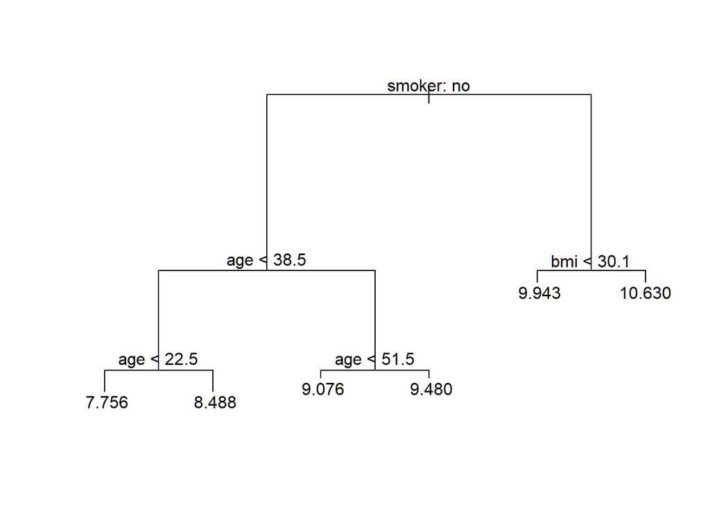

```r
plot(prune.insurance.tree.model)
text(prune.insurance.tree.model, pretty = 0)
```

#### Step f - Calculate the best RMSE for the best model

```r
yhat_tr = predict(prune.insurance.tree.model, newdata = test)
insurance.tree.model.test = test[,"log_charges"]
RMSE_tr <- mean((yhat_tr-insurance.tree.model.test)^2)
print(RMSE_tr)
```

```
## [1] 0.2093131
```

### Part 4 - Build a random forest model

#### Step a - Build a random forest model using function randomForest(), where log_charges is the response and the predictors are age, sex, bmi, children, smoker, and region.

```r
insurance.forest.model <- randomForest(log_charges ~ age + sex + bmi + children + smoker + region, data=train, importance = TRUE)
summary(insurance.forest.model)
```

```
##                 Length Class  Mode
## call              4    -none- call
## type              1    -none- character
## predicted       936    -none- numeric
## mse             500    -none- numeric
## rsq             500    -none- numeric
## oob.times       936    -none- numeric
## importance       12    -none- numeric
## importanceSD      6    -none- numeric
## localImportance   0    -none- NULL
## proximity         0    -none- NULL
## ntree             1    -none- numeric
## mtry              1    -none- numeric
## forest           11    -none- list
## coefs             0    -none- NULL
## y               936    -none- numeric
## test              0    -none- NULL
## inbag             0    -none- NULL
## terms             3    terms  call
```

#### Step b - Compute the test error (using the test data set).

```r
yhat.rf = predict(insurance.forest.model, newdata = test)
insurance.forest.model.test = test[,"log_charges"]
RMSE_rf <- mean((yhat.rf-insurance.forest.model.test)^2)
print(RMSE_rf)
```

```
## [1] 0.1875917
```

#### Step c - Extract variable importance measure using the importance() function.

```r
importance(insurance.forest.model)
```

```
##             %IncMSE IncNodePurity
## age      104.336633     246.71880
## sex        4.616526       6.91371
## bmi       22.088149      59.15946
## children  29.702452      34.20646
## smoker   148.972412     330.29556
## region     8.590349      16.67310
```

#### Step d - Plot the variable importance using the function, varImpPlot(). Which are the top 3 important predictors in this model?

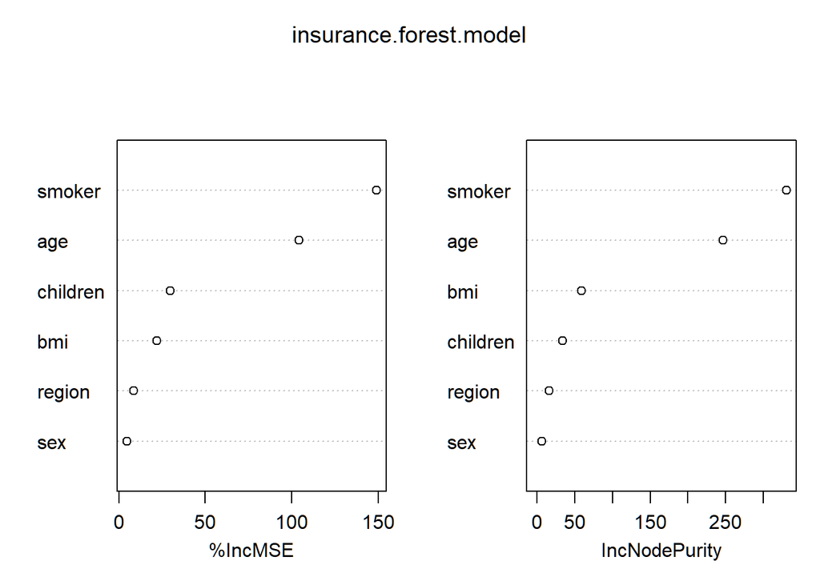

```r
varImpPlot(insurance.forest.model)
```

The top three important predictors in this model based on MSE are smoker, age, and children, and based on Node Purity they are smoker, age, and bmi.

### Part 5 - Perform the K-means cluster analysis

#### Step a - Remove the sex, smoker, and region, since they are not numerical values.

```r
insurance.cluster <- subset(insurance, select = -c(sex, smoker, region))
head(insurance.cluster)
```

```
##   age    bmi children   charges log_charges
## 1  19 27.900        0 16884.924    9.734176
## 2  18 33.770        1  1725.552    7.453302
## 3  28 33.000        3  4449.462    8.400538
## 4  33 22.705        0 21984.471    9.998092
## 5  32 28.880        0  3866.855    8.260197
## 6  31 25.740        0  3756.622    8.231275
```

#### Step b - Determine the optimal number of clusters. Justify your answer.

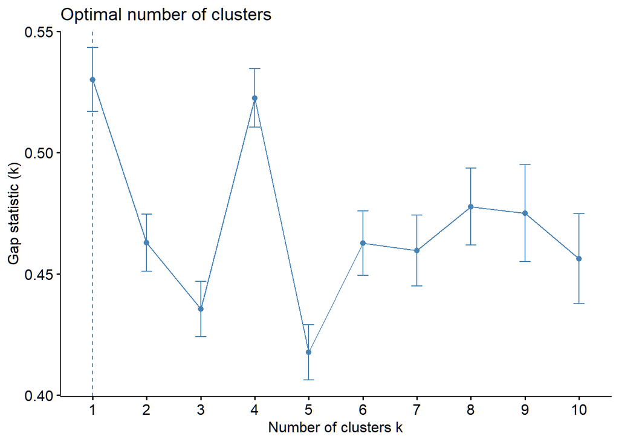

```r
set.seed(1)
fviz_nbclust(insurance.cluster, kmeans, method = "gap_stat")
```

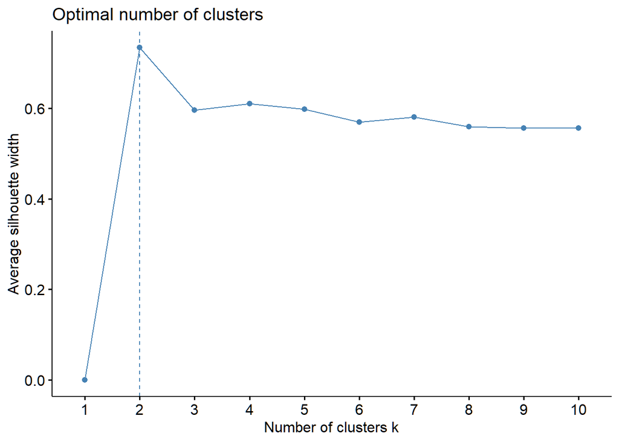

```r
fviz_nbclust(insurance.cluster, kmeans, method = "silhouette")
```

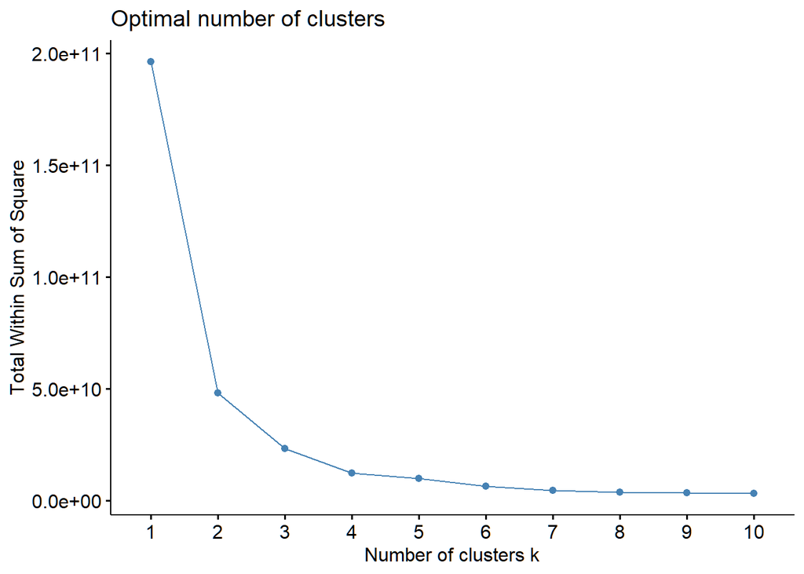

```r
fviz_nbclust(insurance.cluster, kmeans, method = "wss")
```

Based on the results of the Silhouette and Sum of Squares tests, the optimal number of clusters is 2

#### Step c - Perform k-means clustering using the optimal number of clusters from 5b.

```r
km.insurance.cluster <- kmeans(insurance.cluster, 2, nstart = 25)
```

#### Step d - Visualize the clusters in different colors.

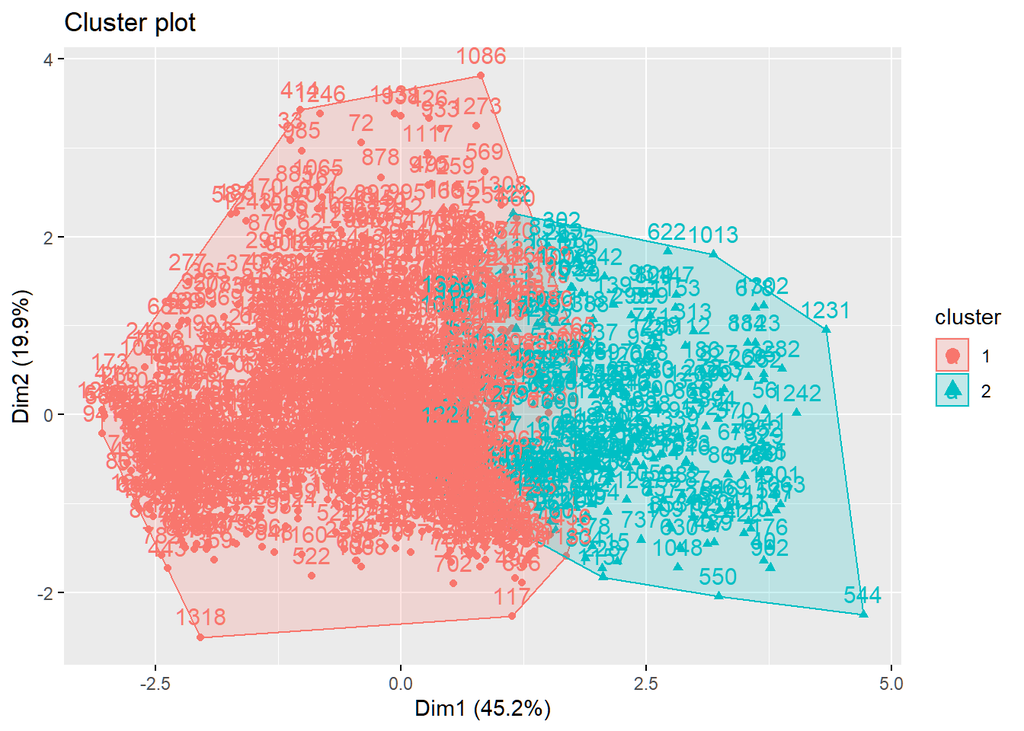

```r
fviz_cluster(km.insurance.cluster, data = insurance.cluster)
```

### Part 6 - Putting it all together

#### Step a - For predicting insurance charges, your supervisor asks you to choose the best model among the multiple regression, regression tree, and random forest. Compare their test RMSEs of the models generated above. Display the names for these types of these models, using these labels: Multiple Linear Regression, Regression Tree, and Random Forest and their corresponding test RMSEs in a data.frame. Label the column in your data frame with the labels as Model.Type, and label the column with the test RMSEs as Test.MSE and round the data in this column to 4 decimal places. Present the formatted data to your supervisor and recommend which model is best and why.

```r
Model.Type <- c("Multiple Linear Regression","Regression Tree","Random Forest")
Test.MSE <- c(round(RMSE_mr,digits=4),round(RMSE_tr,digits=4),round(RMSE_rf,digits=4))
model_results <- data.frame(Model.Type, Test.MSE)
print(model_results, row.names = FALSE)
```

```
##                  Model.Type Test.MSE
##  Multiple Linear Regression   0.2392
##             Regression Tree   0.2093
##               Random Forest   0.1876
```

A Random Forest model is the recommended choice for predicting insurance charges. Its use will result in the least amount of error generated for the data provided, resulting in more accurate predictions.

#### Step b - Another supervisor from the sales department has requested your help to create a predictive model that his sales representatives can use to explain to clients what the potential costs could be for different kinds of customers, and they need an easy and visual way of explaining it. What model would you recommend, and what are the benefits and disadvantages of your recommended model compared to other models?

I would recommend the Regression Tree model for sales representatives to use. It is the most visual of the models, and is easy to follow the breakdowns of results, making it a good choice for explaining potential costs to a client. The downside of using it is in that it has slightly less accuracy than the Random Forest model; but, if the understanding is that it should be used for estimation purposes only and not for hard negotiated contracts, it should be acceptable.

#### Step c - The supervisor from the sales department likes your regression tree model. But she says that the salespeople say the numbers in it are way too low and suggests that maybe the numbers on the leaf nodes predicting charges are log transformations of the actual charges. You realize that in step 1.b of this project that you had indeed transformed charges using the log function. And now you realize that you need to reverse the transformation in your final output. The solution you have is to reverse the log transformation of the variables in the regression tree model you created and redisplay the result.

##### Follow these steps:

- Copy your pruned tree model to a new variable name.
- In your new variable, find the data.frame named “frame” and reverse the log transformation on the data.frame column yval using the exp() function. (If the copy of your pruned tree model is named copy_of_my_pruned_tree, then the data frame is accessed as copy_of_my_pruned_tree$frame, and it works just like a normal data frame.).
- After you reverse the log transform on the yval column, then replot the tree with labels.

```r
unlog.tree.model <- prune.insurance.tree.model
print(unlog.tree.model$frame$yval)
```

```
##  [1]  9.086919  8.777691  8.249924  7.756424  8.487610  9.279208  9.075883
##  [8]  9.480415 10.293069  9.943183 10.625103
```

```r
unlog.tree.model$frame$yval <- exp(unlog.tree.model$frame$yval)
print(unlog.tree.model$frame$yval)
```

```
##  [1]  8838.911  6487.881  3827.335  2336.534  4854.249 10712.948  8741.904
##  [8] 13100.627 29527.250 20809.882 41155.100
```

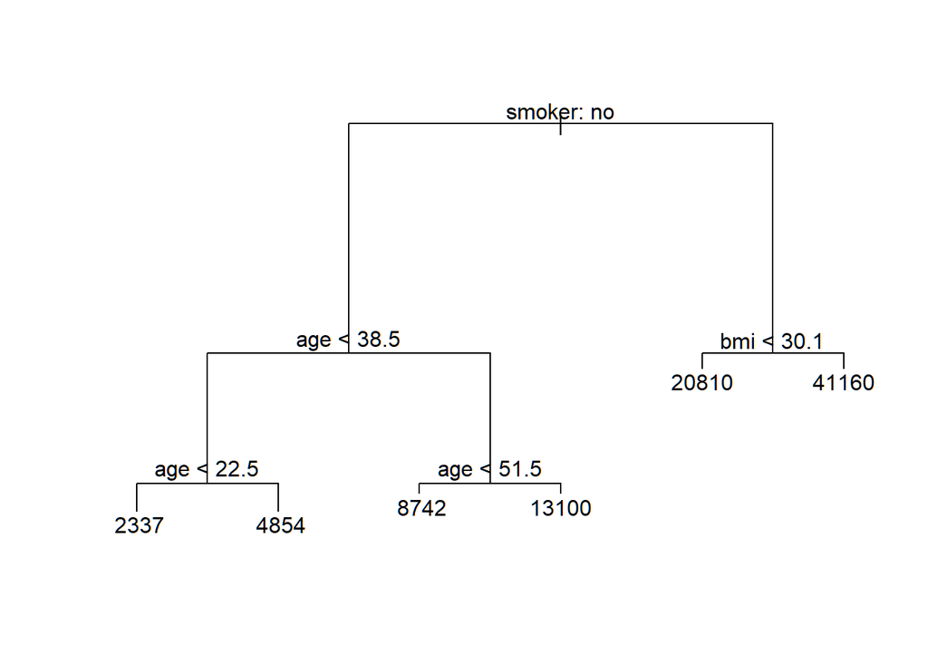

```r
plot(unlog.tree.model)
text(unlog.tree.model, pretty = 0)
```